# Does Renewable Energy Consumption Affect the Growth of GDP Per Capita?

#### Appendix

The pattern for gross capital formation and GDP per capita growth slightly changes around 25% of gross capital formation. This result suggests that a Piecewise Linear Spline regression should be used for comparison.

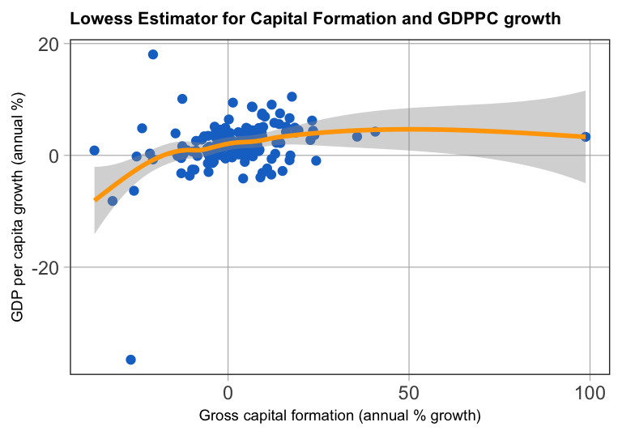

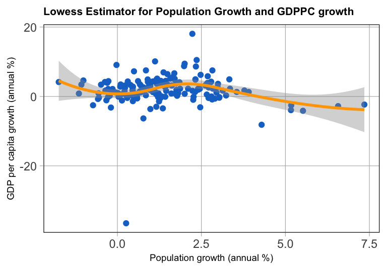

The pattern for population growth and GDP per capita growth seems to be nonlinear, and the pattern for log of trade and GDP per capita growth is linear. It also seems there is a different average for developed and developing countries.

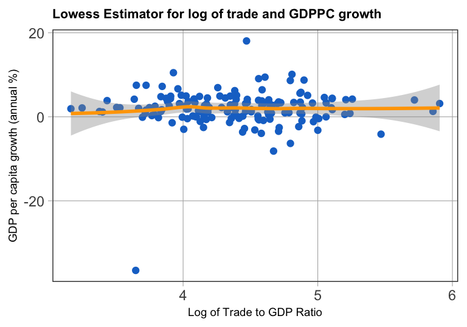

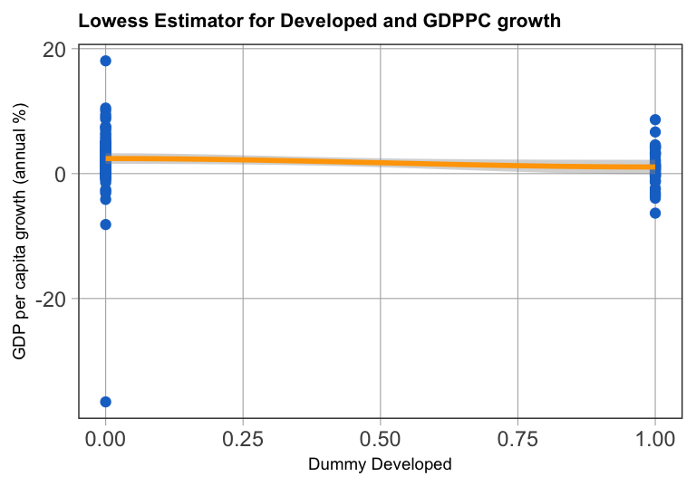

Correlation Matrix

|  | developed | renewable_eng | gdppc_growth | capital_formation | pop_growth | ln_trade |
| --- | --- | --- | --- | --- | --- | --- |
| developed | 1.0000000 | -0.4387747 | -0.1460936 | -0.0905920 | -0.3308649 | 0.3039648 |
| renewable_eng | -0.4387747 | 1.0000000 | 0.0957550 | 0.0370302 | 0.2680783 | -0.3480041 |
| gdppc_growth | -0.1460936 | 0.0957550 | 1.0000000 | 0.2845089 | -0.0402565 | 0.0331117 |
| capital_formation | -0.0905920 | 0.0370302 | 0.2845089 | 1.0000000 | 0.1502293 | 0.0046060 |
| pop_growth | -0.3308649 | 0.2680783 | -0.0402565 | 0.1502293 | 1.0000000 | -0.0821324 |
| ln_trade | 0.3039648 | -0.3480041 | 0.0331117 | 0.0046060 | -0.0821324 | 1.0000000 |

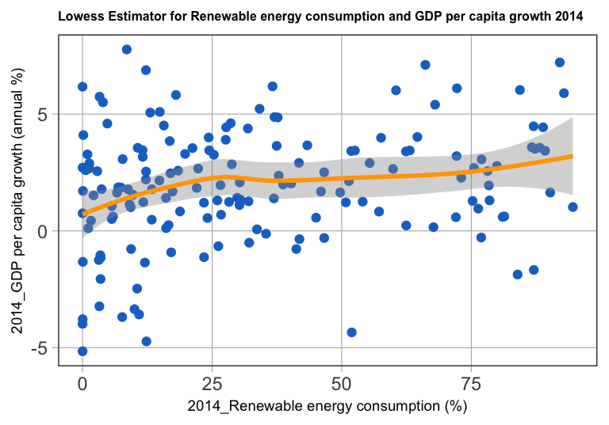

Robustness Check Results Table

|  | (4) | (6) |
| --- | --- | --- |
| (Intercept) | -4.21 | -3.18 |
|  | (3.50) | (2.22) |
| lspline(renewable_eng, 25)1 | 0.10 ** | 0.05 |
|  | (0.04) | (0.03) |
| lspline(renewable_eng, 25)2 | -0.02 | 0.01 |
|  | (0.02) | (0.01) |
| developed | -1.22 * | -0.56 |
|  | (0.55) | (0.40) |
| lspline(capital_formation, 25)1 | 0.14 * | 0.06 |
|  | (0.07) | (0.04) |
| lspline(capital_formation, 25)2 | -0.04 | -0.08 |
|  | (0.04) | (0.04) |
| ln_trade | 1.12 | 0.95 * |
|  | (0.75) | (0.48) |
| nobs | 161 | 160 |
| r.squared | 0.16 | 0.18 |
| adj.r.squared | 0.13 | 0.15 |
| statistic | 5.82 | 4.67 |
| p.value | 0.00 | 0.00 |
| df.residual | 154.00 | 153.00 |
| nobs.1 | 161.00 | 160.00 |
| se_type | HC2.00 | HC2.00 |
| *** p < 0.001; ** p < 0.01; * p < 0.05. |  |  |